# Indel Signature InsDel_L

# InsDel_L

**Note**

(corresponds to 83-type signature ID_L)

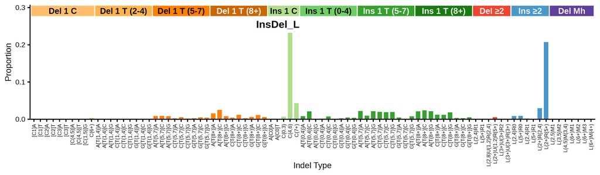

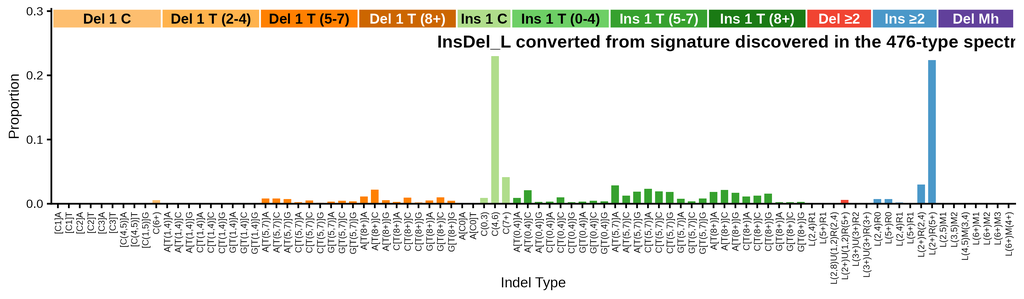

89-type spectrum of the linking tumor CPCT02450014T | cosine similarity to InsDel_L: 0.9658

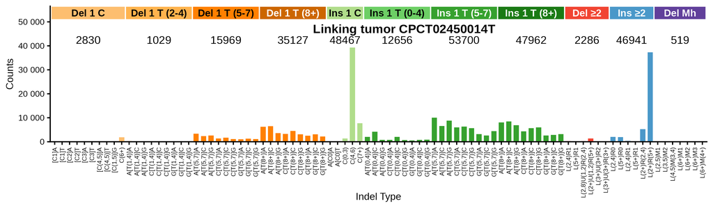

**Click to view decomposition of the linking tumor spectrum**

Partial mutation signature of CPCT02450014T due to InsDel_L

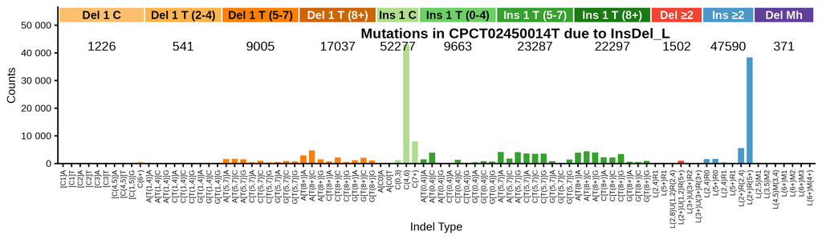

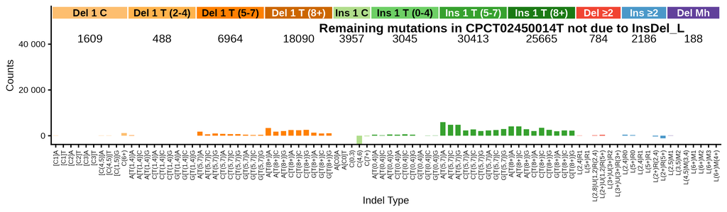

Max neg fraction (maximum allowed negative residual count as fraction of total): 0.02  
N subtract (mutation count assigned to signature): 184794.6  
N residual (mutation count in residual “partial spectrum”): 82691.4  
Total negative (sum of negative residual mutation counts): 5349.6  
N negative channels (number of channels with negative residual): 9  
P(≥ total negative) (Monte Carlo estimated probability that negative-binomial-sampled spectra from the signature contributing N subtract mutations would produce a total negative count >= the observed Total negative; higher number means not surprising): 0.733

**Per-channel residual breakdown**

| Channel | Spectrum | Sig_Count | Residual | Sig_Prop |
| --- | --- | --- | --- | --- |
| [Del(C):R1]A | 170 | 83.6 | 86.4 | 0.00045 |
| [Del(C):R1]T | 124 | 78.2 | 45.8 | 0.00042 |
| [Del(C):R2]A | 42 | 41.7 | 0.3 | 0.00023 |
| [Del(C):R2]T | 91 | 70.2 | 20.8 | 0.00038 |
| [Del(C):R3]A | 32 | 25.1 | 6.9 | 0.00014 |
| [Del(C):R3]T | 44 | 46.6 | -2.6 | 0.00025 |
| [Del(C):R(4,5)]A | 158 | 55.9 | 102.1 | 0.00030 |
| [Del(C):R(4,5)]T | 233 | 114.2 | 118.8 | 0.00062 |
| [Del(C):R(1,5)]G | 115 | 70.1 | 44.9 | 0.00038 |
| Del(C):R(6,9) | 1821 | 640.3 | 1180.7 | 0.00346 |
| A[Del(T):R(1,4)]A | 320 | 109.0 | 211 | 0.00059 |
| A[Del(T):R(1,4)]C | 113 | 52.2 | 60.8 | 0.00028 |
| A[Del(T):R(1,4)]G | 114 | 59.5 | 54.5 | 0.00032 |
| C[Del(T):R(1,4)]A | 127 | 88.6 | 38.4 | 0.00048 |
| C[Del(T):R(1,4)]C | 124 | 79.4 | 44.6 | 0.00043 |
| C[Del(T):R(1,4)]G | 58 | 34.2 | 23.8 | 0.00019 |
| G[Del(T):R(1,4)]A | 67 | 47.0 | 20 | 0.00025 |
| G[Del(T):R(1,4)]C | 49 | 36.6 | 12.4 | 0.00020 |
| G[Del(T):R(1,4)]G | 57 | 34.1 | 22.9 | 0.00018 |
| A[Del(T):R(5,7)]A | 3348 | 1581.1 | 1766.9 | 0.00856 |
| A[Del(T):R(5,7)]C | 2349 | 1660.2 | 688.8 | 0.00898 |
| A[Del(T):R(5,7)]G | 2587 | 1570.0 | 1017 | 0.00850 |
| C[Del(T):R(5,7)]A | 1332 | 495.3 | 836.7 | 0.00268 |
| C[Del(T):R(5,7)]C | 1727 | 1027.0 | 700 | 0.00556 |
| C[Del(T):R(5,7)]G | 1111 | 365.5 | 745.5 | 0.00198 |
| G[Del(T):R(5,7)]A | 1047 | 548.8 | 498.2 | 0.00297 |
| G[Del(T):R(5,7)]C | 1313 | 991.0 | 322 | 0.00536 |
| G[Del(T):R(5,7)]G | 1155 | 766.1 | 388.9 | 0.00415 |
| A[Del(T):R(8,)]A | 6278 | 2925.9 | 3352.1 | 0.01583 |
| A[Del(T):R(8,)]C | 6466 | 4711.5 | 1754.5 | 0.02550 |

[output cut: 59 more lines]

## 476-type representations corresponding to InsDel_L

Extracted 476-type signature corresponding to InsDel_L

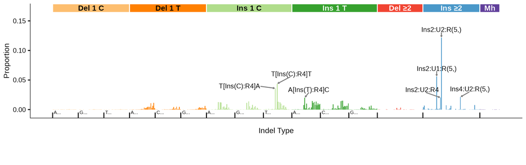

476-type spectrum of the linking tumor CPCT02450014T; cosine similarity to the extracted 476-type signature is 0.9406

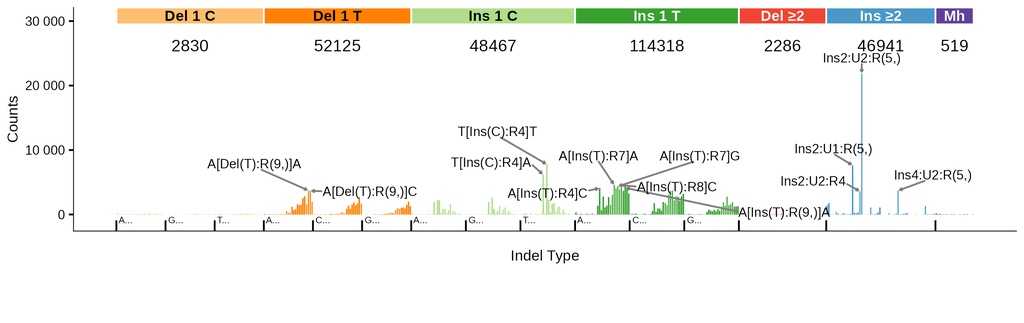

## 83-type signature corresponding to InsDel_L (ID_L)

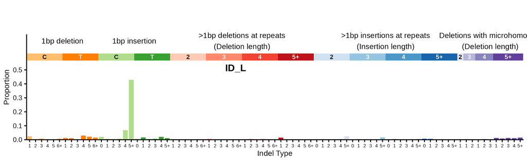

83-type signature converted from signature discovered in the 476-type spectra (using bipartite matching optimization) | cosine similarity to ID_L: 0.4916

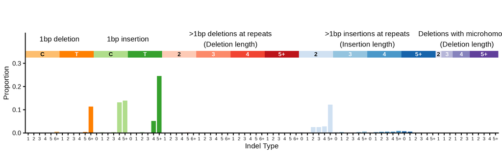

**Click here to see with insertions and deletions of T in long poly-T suppressed**

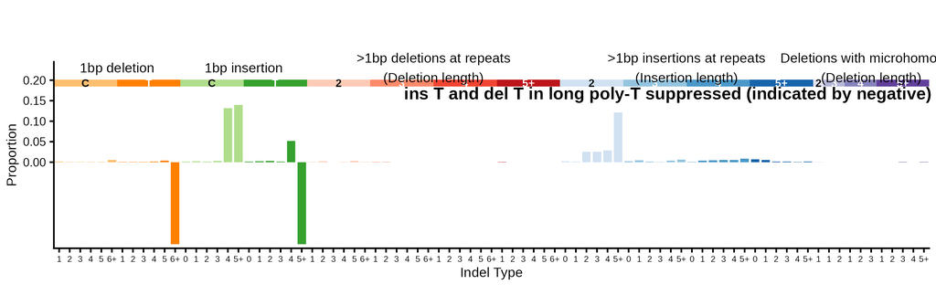

**Click to see flow diagrams: 476-type to 83-type collapse**

These Sankey diagrams show how the 476-type mutation categories are redistributed to 83-type categories using bipartite matching. We only show the diagrams for insertions or deletions of > 1 base because it is for these indels that 476-type categories map to > 1 83-type category.

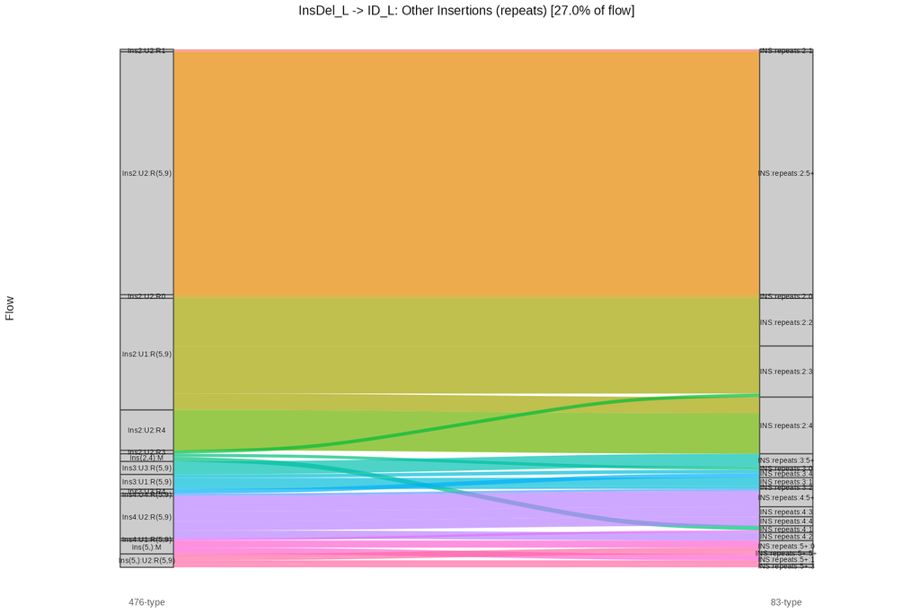

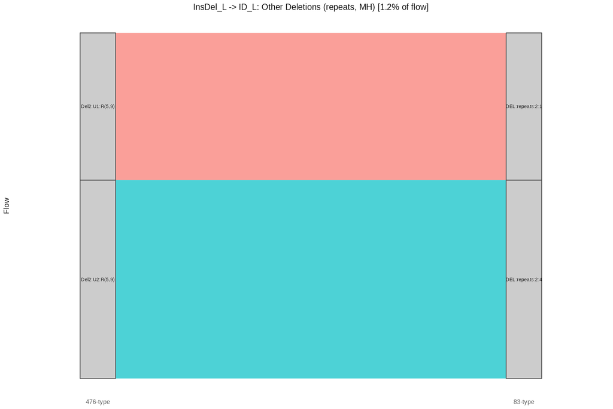

83-type spectrum of the linking tumor CPCT02450014T | cosine similarity to ID_L: 0.275

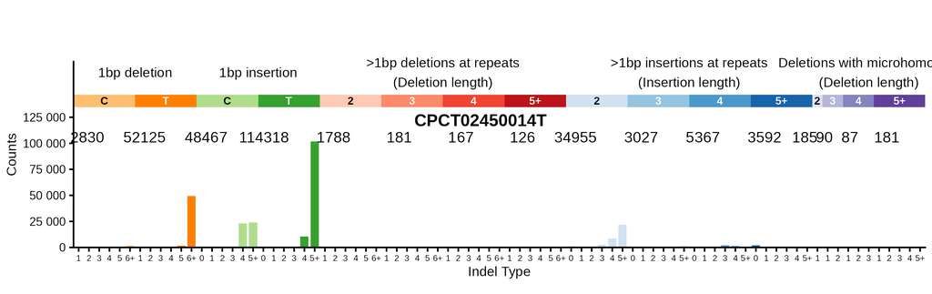

**Click here to see with insertions and deletions of T in long poly-T suppressed**

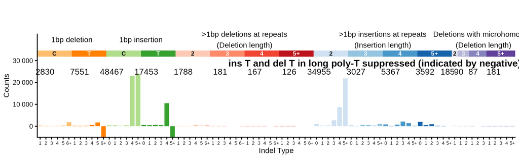

83-type spectrum of best 83-type matching tumor SP70106 | cosine similarity to ID_L: 0.587

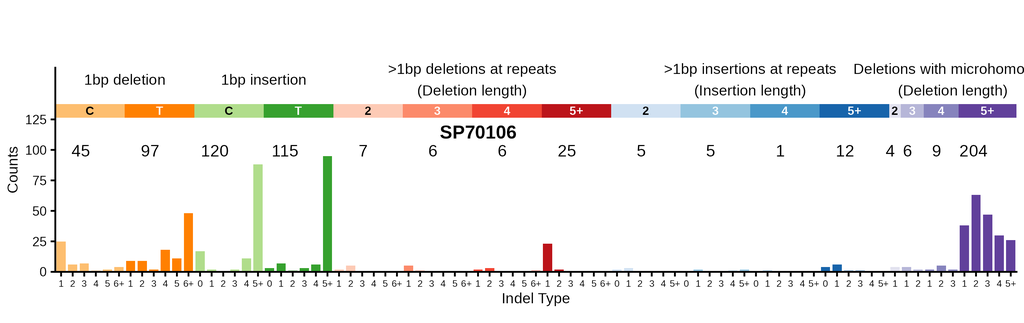